[OHI British Columbia](http://www.ohibc.org/) | [OHI Science](http://ohi-science.org) | [Citation policy](https://github.com/OHI-Science/ohiprep/releases)

# Regress health and trend vs MPAs

Compiled on Tue Jan 30 15:04:08 2018 by ohara

```r
knitr::opts_chunk$set(fig.width = 6, fig.height = 4, fig.path = 'Figs/',
                      echo = TRUE, message = FALSE, warning = FALSE)

library(raster)
library(sf)
library(fasterize)

source('~/github/src/R/common.R')  ###
  ### includes library(tidyverse); library(stringr); dir_M points to ohi directory

dir_git <- '~/github/spp_health_dists'

### goal specific folders and info
dir_setup   <- file.path(dir_git, 'data_setup')
dir_spatial <- file.path(dir_git, 'spatial')
dir_anx     <- file.path(dir_M, 'git-annex')
dir_o_anx   <- file.path(dir_O, 'git-annex/spp_health_dists')
# ### provenance tracking
library(provRmd); prov_setup()

### support scripts
source('~/github/src/R/rast_tools.R')
  ### raster plotting and analyzing scripts

thresh <- .01
thresh_tag <- '01'
sample_df_file <- file.path(dir_o_anx, 'samples', paste0('sample_dataframe_', thresh_tag, '.csv'))
```

# 1 Summary

Using the LOICZID raster and rasters of WDPA and MEOW regions, create crosstabs of AquaMaps cells per each zone or protection year

# 2 Data Sources

# 3 Methods

## 3.1 Build data frame

Using the random ocean raster, set a threshold to sample a proportion of cells (e.g. p = .01 is 1% of ocean cells). From this, build a dataframe of these cells with the following info:

- LOICZID (for attaching species health and trend info)
- risk and trend by LOICZID
- MPA year
- MEOW ID number

```r
rand_ocean_rast  <- raster(file.path(dir_o_anx, 'spatial/rand_ocean_base.tif'))

if(!file.exists(sample_df_file)) {

  sample_rast_file <- file.path(dir_o_anx, 'samples', sprintf('rand_ocean_sample_%s.tif', thresh_tag))

  if(!file.exists(sample_rast_file)) {
    ocean_sample_rast <- rand_ocean_rast %>%
      calc(fun = function(x) ifelse(x > thresh, NA, 1),
           filename = sample_rast_file)
  }
  ocean_sample_rast <- raster(sample_rast_file)


  loiczid_sample_file <- file.path(dir_o_anx, 'samples', sprintf('loiczid_sample_%s.tif', thresh_tag))
  if(!file.exists(loiczid_sample_file)) {
    # cat('creating LOICZID sample raster\n')
    loiczid_sample <- raster(file.path(dir_o_anx, 'spatial/loiczid_moll_934m.tif')) %>%
      mask(ocean_sample_rast,
           # progress = 'text',
           filename = loiczid_sample_file)
  }
  loiczid_sample <- raster(loiczid_sample_file)


  # wdpa_marine_all  <- raster(file.path(dir_o_anx, 'wdpa/wdpa_mar_all_dec2017.tif'))
  # wdpa_marine_i_vi <- raster(file.path(dir_o_anx, 'wdpa/wdpa_mar_i_vi_dec2017.tif'))
  wdpa_sample_file <- file.path(dir_o_anx, 'samples', sprintf('wdpa_i_iv_sample_%s.tif', thresh_tag))
  if(!file.exists(wdpa_sample_file)) {
    # cat('creating WDPA sample raster\n')
    wdpa_sample <- raster(file.path(dir_o_anx, 'wdpa/wdpa_mar_i_iv_dec2017.tif')) %>%
      mask(ocean_sample_rast,
           # progress = 'text',
           filename = wdpa_sample_file)
  }
  wdpa_marine_i_iv_sample <- raster(wdpa_sample_file)


  meow_sample_file <- file.path(dir_o_anx, 'samples', sprintf('meow_sample_%s.tif', thresh_tag))
  if(!file.exists(meow_sample_file)) {
    # cat('creating MEOW sample raster\n')
    meow_sample <- raster(file.path(dir_o_anx, 'meow/meow_rast_934m.tif')) %>%
      mask(ocean_sample_rast,
           # progress = 'text',
           filename = meow_sample_file)
  }
  meow_sample <- raster(meow_sample_file)


  big_df <- data.frame(loiczid = values(loiczid_sample),
                       mpa_yr  = values(wdpa_sample),
                       meow_id = values(meow_sample)) %>%
    filter(!is.na(loiczid)) %>%
    mutate(mpa_yr  = as.integer(mpa_yr),
           meow_id = as.integer(meow_id))

  risk_df  <- read_csv(file.path(dir_git, 'data/current_risk_by_loiczid.csv'),
                       col_types = 'iid')
  trend_df <- read_csv(file.path(dir_git, 'data/spp_trend_by_loiczid.csv'),
                       col_types = 'iid')

  big_df <- big_df %>%
    left_join(risk_df %>% rename(n_spp_risk = n_spp), by = 'loiczid') %>%
    left_join(trend_df %>% rename(n_spp_trend = n_spp), by = 'loiczid')

  write_csv(big_df, sample_df_file)
}
```

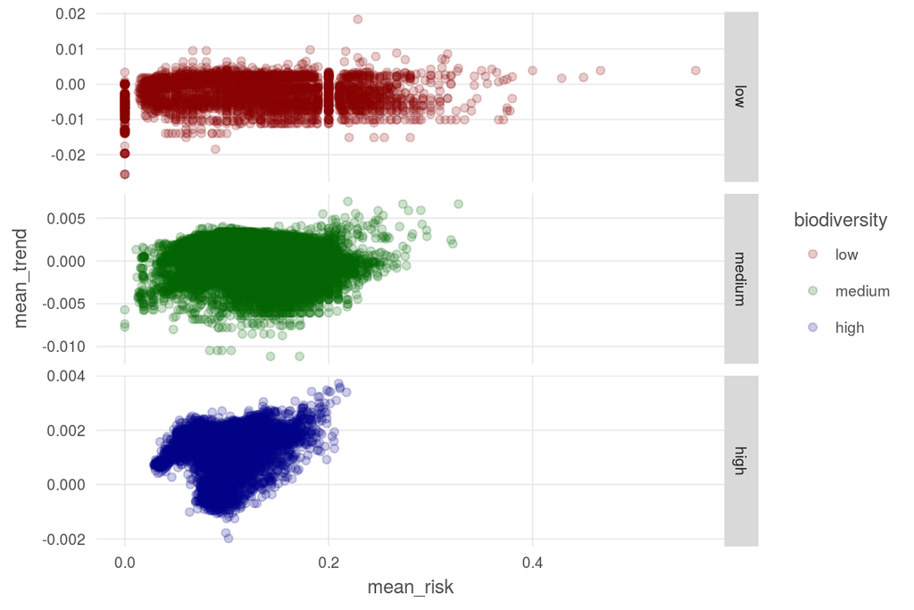

```r
big_df <- read_csv(sample_df_file, col_types = 'iiiidid')

risk_trend_df <- big_df %>%
  select(mean_risk, mean_trend, n_spp_risk, n_spp_trend) %>%
  filter(!is.na(mean_risk) & !is.na(mean_trend)) %>%
  mutate(biodiversity = case_when(n_spp_risk <= 20 ~ 'low',
                                  n_spp_risk > 20 & n_spp_risk <= 100 ~ 'medium',
                                  n_spp_risk > 100 ~ 'high',
                                  TRUE ~ 'oops'),
         biodiversity = factor(biodiversity, levels = c('low', 'medium', 'high')))

# quantile(risk_trend_df$n_spp_risk, c(0.10, 0.5, 0.9, .95), na.rm = TRUE)
# 10%   50%   90%   95%
#   8    36    68   138

ggplot(risk_trend_df %>% filter(n_spp_risk >= 5) %>% distinct(), aes(x = mean_risk, y = mean_trend)) +
  geom_point(aes(color = biodiversity), alpha = .2) +
  scale_color_manual(values = c('low' = 'darkred', 'medium' = 'darkgreen', 'high' = 'darkblue')) +
  ggtheme_plot() +
  facet_grid(biodiversity ~ ., scales = 'free_y')
```

```r
big_df <- read_csv(sample_df_file, col_types = 'iiiidid')

mpa_risk_trend_df <- big_df %>%
  select(mpa_yr, mean_risk, mean_trend, n_spp_risk, n_spp_trend) %>%
  filter(!is.na(mean_risk)) %>%
  mutate(biodiversity = case_when(n_spp_risk <= 20 ~ 'low',
                                  n_spp_risk >  20 & n_spp_risk <= 100 ~ 'medium',
                                  n_spp_risk > 100 ~ 'high',
                                  TRUE ~ 'oops'),
         biodiversity = factor(biodiversity, levels = c('low', 'medium', 'high'))) %>%
  mutate(protected = !is.na(mpa_yr),
         mpa_age   = ifelse(!is.na(mpa_yr) & mpa_yr < 2000, 'old', 'new'))
```

### 3.1.1 Mean risk, MPA vs no MPA

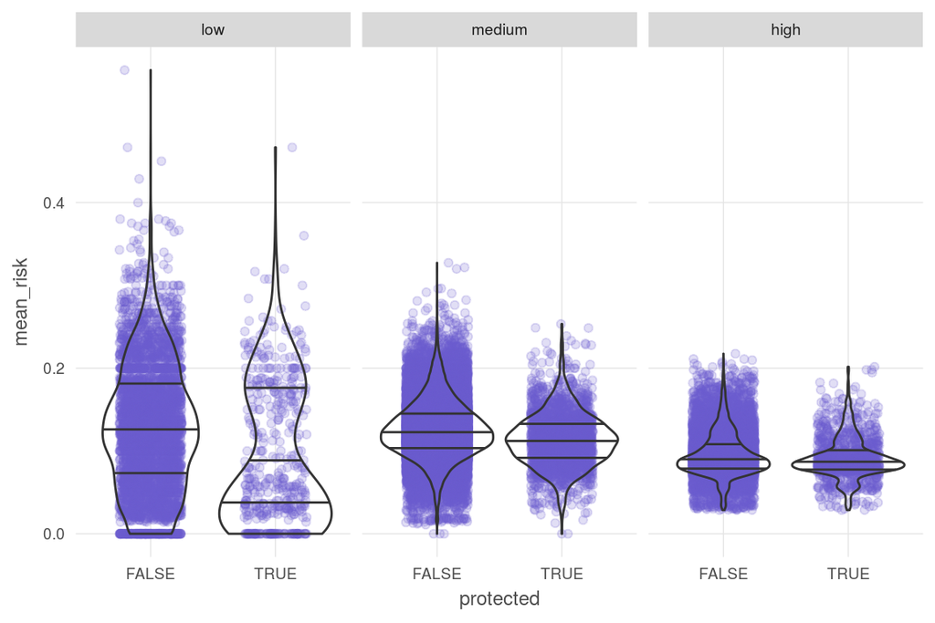

```r
ggplot(mpa_risk_trend_df %>%
         filter(n_spp_risk >= 5) %>% distinct(),
       aes(x = protected, y = mean_risk)) +
  geom_jitter(alpha = .2, height = 0, width = .25, color = 'slateblue') +
  geom_violin(fill = NA, draw_quantiles = c(.25, .5, .75)) +
  ggtheme_plot() +
  facet_grid(. ~ biodiversity)
```

```r
risk_mpa_vs_nompa <- lm(mean_risk ~ protected, data = mpa_risk_trend_df)
summary(risk_mpa_vs_nompa)
```

```
##
## Call:
## lm(formula = mean_risk ~ protected, data = mpa_risk_trend_df)
##
## Residuals:
##      Min       1Q   Median       3Q      Max
## -0.13857 -0.02948 -0.00780  0.03066  0.66143
##
## Coefficients:
##                 Estimate Std. Error t value Pr(>|t|)
## (Intercept)    1.386e-01  2.961e-05  4679.6   <2e-16 ***
## protectedTRUE -1.697e-02  2.084e-04   -81.4   <2e-16 ***
## ---
## Signif. codes:  0 '***' 0.001 '**' 0.01 '*' 0.05 '.' 0.1 ' ' 1
##
## Residual standard error: 0.05888 on 4035954 degrees of freedom
## Multiple R-squared:  0.001639,   Adjusted R-squared:  0.001639
## F-statistic:  6626 on 1 and 4035954 DF,  p-value: < 2.2e-16
```

### 3.1.2 Mean trend, MPA vs no MPA

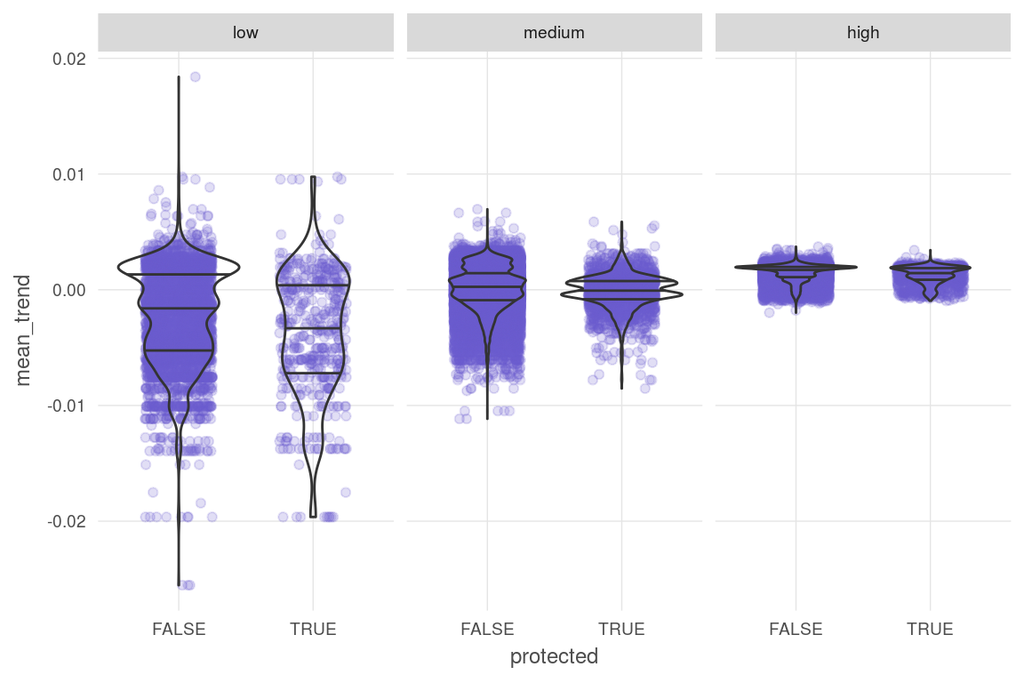

```r
ggplot(mpa_risk_trend_df %>%
         filter(n_spp_risk >= 5) %>% distinct(),
       aes(x = protected, y = mean_trend)) +
  geom_jitter(alpha = .2, height = 0, width = .25, color = 'slateblue') +
  geom_violin(fill = NA, draw_quantiles = c(.25, .5, .75)) +
  ggtheme_plot() +
  facet_grid(. ~ biodiversity)
```

```r
trend_mpa_vs_nompa <- lm(mean_trend ~ protected, data = mpa_risk_trend_df)
summary(trend_mpa_vs_nompa)
```

```
##
## Call:
## lm(formula = mean_trend ~ protected, data = mpa_risk_trend_df)
##
## Residuals:
##        Min         1Q     Median         3Q        Max
## -0.0249662 -0.0006757  0.0011654  0.0026416  0.0282987
##
## Coefficients:
##                 Estimate Std. Error  t value Pr(>|t|)
## (Intercept)   -6.987e-04  1.912e-06 -365.406   <2e-16 ***
## protectedTRUE  1.350e-04  1.353e-05    9.973   <2e-16 ***
## ---
## Signif. codes:  0 '***' 0.001 '**' 0.01 '*' 0.05 '.' 0.1 ' ' 1
##
## Residual standard error: 0.00378 on 3988038 degrees of freedom
##   (47916 observations deleted due to missingness)
## Multiple R-squared:  2.494e-05,  Adjusted R-squared:  2.469e-05
## F-statistic: 99.46 on 1 and 3988038 DF,  p-value: < 2.2e-16
```

### 3.1.3 Mean risk, old MPA vs new MPA

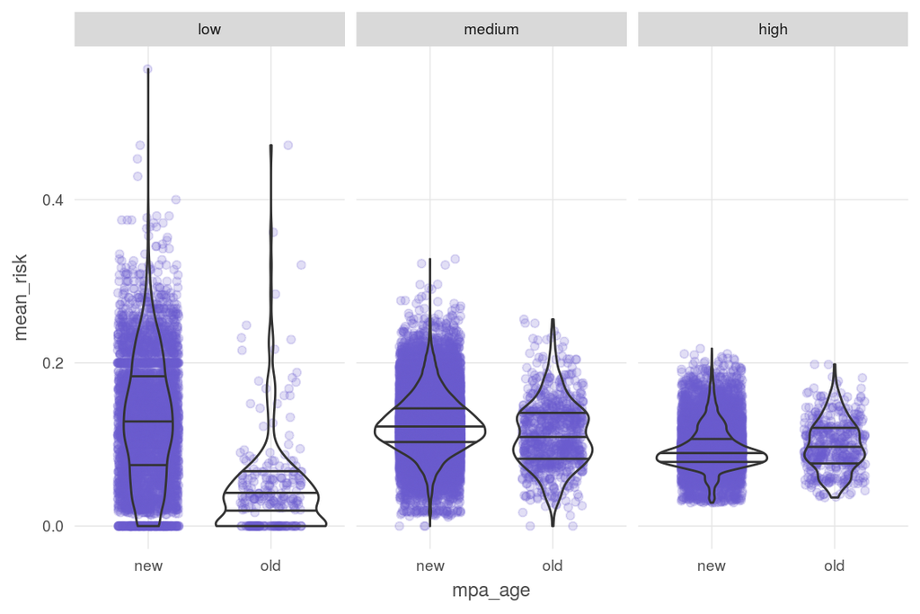

```r
ggplot(mpa_risk_trend_df %>%
         filter(n_spp_risk >= 5) %>% distinct(),
       aes(x = mpa_age, y = mean_risk)) +
  geom_jitter(alpha = .2, height = 0, width = .25, color = 'slateblue') +
  geom_violin(fill = NA, draw_quantiles = c(.25, .5, .75)) +
  ggtheme_plot() +
  facet_grid(. ~ biodiversity)
```

```r
risk_mpa_old_v_new <- lm(mean_risk ~ mpa_age, data = mpa_risk_trend_df)
summary(risk_mpa_old_v_new)
```

```
##
## Call:
## lm(formula = mean_risk ~ mpa_age, data = mpa_risk_trend_df)
##
## Residuals:
##      Min       1Q   Median       3Q      Max
## -0.13840 -0.02931 -0.00797  0.03083  0.66160
##
## Coefficients:
##               Estimate Std. Error t value Pr(>|t|)
## (Intercept)  1.384e-01  2.938e-05 4711.42   <2e-16 ***
## mpa_ageold  -3.754e-02  4.294e-04  -87.43   <2e-16 ***
## ---
## Signif. codes:  0 '***' 0.001 '**' 0.01 '*' 0.05 '.' 0.1 ' ' 1
##
## Residual standard error: 0.05888 on 4035954 degrees of freedom
## Multiple R-squared:  0.00189,    Adjusted R-squared:  0.00189
## F-statistic:  7644 on 1 and 4035954 DF,  p-value: < 2.2e-16
```

### 3.1.4 Mean trend, old MPA vs new MPA

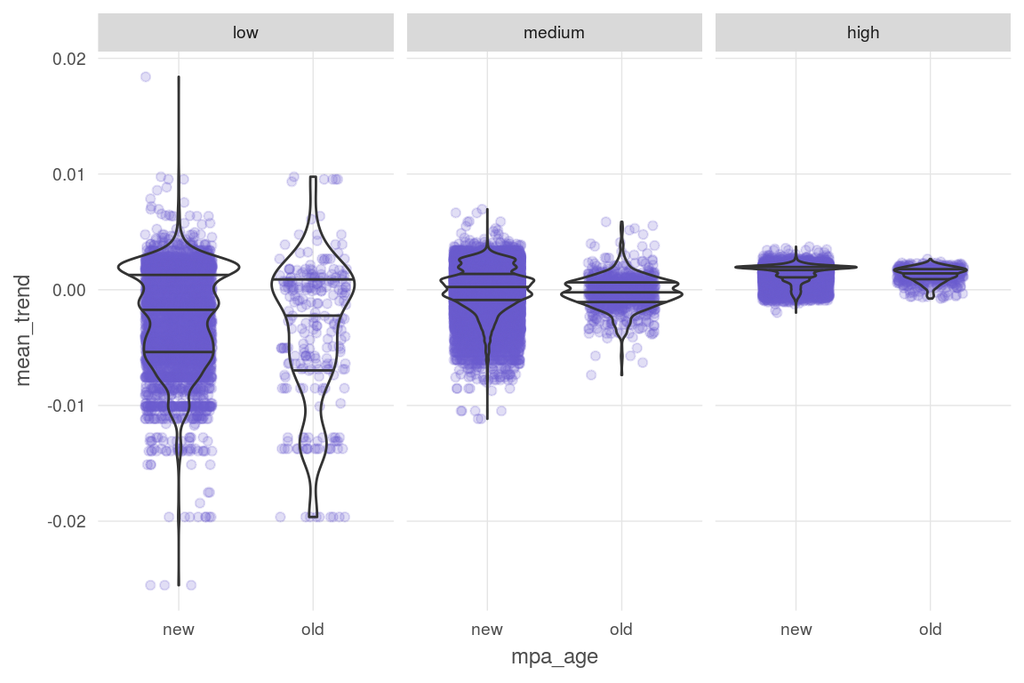

```r
ggplot(mpa_risk_trend_df %>%
         filter(n_spp_risk >= 5) %>% distinct(),
       aes(x = mpa_age, y = mean_trend)) +
  geom_jitter(alpha = .2, height = 0, width = .25, color = 'slateblue') +
  geom_violin(fill = NA, draw_quantiles = c(.25, .5, .75)) +
  ggtheme_plot() +
  facet_grid(. ~ biodiversity)
```

```r
trend_mpa_old_v_new <- lm(mean_trend ~ mpa_age, data = mpa_risk_trend_df)
summary(trend_mpa_old_v_new)
```

```
##
## Call:
## lm(formula = mean_trend ~ mpa_age, data = mpa_risk_trend_df)
##
## Residuals:
##        Min         1Q     Median         3Q        Max
## -0.0249497 -0.0006779  0.0011632  0.0026394  0.0282965
##
## Coefficients:
##               Estimate Std. Error  t value Pr(>|t|)
## (Intercept) -6.965e-04  1.897e-06 -367.132  < 2e-16 ***
## mpa_ageold   1.163e-04  2.834e-05    4.103 4.08e-05 ***
## ---
## Signif. codes:  0 '***' 0.001 '**' 0.01 '*' 0.05 '.' 0.1 ' ' 1
##
## Residual standard error: 0.00378 on 3988038 degrees of freedom
##   (47916 observations deleted due to missingness)
## Multiple R-squared:  4.221e-06,  Adjusted R-squared:  3.97e-06
## F-statistic: 16.83 on 1 and 3988038 DF,  p-value: 4.084e-05
```

```r
prov_wrapup(commit_outputs = FALSE)
```

# 4 Provenance

- *Run ID: 2 (29dca36); run tag: “standard run”*
- *Run elapsed time: 138.422 seconds; run memory usage: 11088.9 MB*
- *System info:*
  - *System: Linux, Release: 4.4.0-57-generic. Machine: x86_64. User: ohara.*
  - *R version: R version 3.4.3 (2017-11-30), Platform: x86_64-pc-linux-gnu, Running under: Ubuntu 14.04.5 LTS.*
  - *Attached base packages: stats, graphics, grDevices, utils, datasets, methods, base*
  - *Other attached packages: bindrcpp_0.2, provRmd_0.1.1, stringr_1.2.0, RColorBrewer_1.1-2, dplyr_0.7.2, purrr_0.2.3, readr_1.1.0, tidyr_0.7.0, tibble_1.3.4, ggplot2_2.2.1.9000, tidyverse_1.1.1, fasterize_0.1.0, sf_0.5-5, raster_2.5-8, sp_1.2-5*

[figure not shown]

| sequence | file_name | parent_chunk | file_dir | filetype | uncomm_chgs | commit_hash_short |
| --- | --- | --- | --- | --- | --- | --- |
| 0 | 1_regress_health_trend_mpas.Rmd | prov_footer | ~/github/spp_health_dists | parent_script |  |  |
| 0 | 1_regress_health_trend_mpas.Rmd#compare_trend_to_risk | compare_trend_to_risk | ~/github/spp_health_dists | parent_chunk |  |  |
| 0 | 1_regress_health_trend_mpas.Rmd#get_rasts | get_rasts | ~/github/spp_health_dists | parent_chunk |  |  |
| 0 | 1_regress_health_trend_mpas.Rmd#prov_footer | prov_footer | ~/github/spp_health_dists | parent_chunk |  |  |
| 0 | 1_regress_health_trend_mpas.Rmd#setup | setup | ~/github/spp_health_dists | parent_chunk |  |  |
| 0 | 1_regress_health_trend_mpas.Rmd#set_up_mpa_df | set_up_mpa_df | ~/github/spp_health_dists | parent_chunk |  |  |
| 1 | rast_tools.R | setup | ~/github/src/R | sourced_script |  |  |
| 2 | rand_ocean_base.tif | get_rasts | ~/git-annex/spp_health_dists/spatial | input |  |  |
| 3 | sample_dataframe_01.csv | compare_trend_to_risk | ~/git-annex/spp_health_dists/samples | input |  |  |
| 4 | sample_dataframe_01.csv | set_up_mpa_df | ~/git-annex/spp_health_dists/samples | input |  |  |